# Evaluation of the VCF result from GATK

Mar Llaberia-Robledillo & J. Ignacio Lucas Lledó

2023-05-23

On `2023-05-18` GATK obtained a large VCF with SNP calls among all the ddRAD samples. The VCF is a very incomplete matrix of genotypes. We need describe the missingness in that matrix. How many SNPs are genotyped in at least *n* samples? What samples have less than a certain fraction of SNPs genotyped? We use `vcftools` to answer these questions.

# Individual Filtering Options

There may be some individuals with low data. Before deciding what individuals to remove from the data set (i) we need to see the proportion of sites per individual, and (ii) we need to see the proportion of data they miss.

The `--missing-indv` option commands `vcftools` to generate a file reporting the missingness on a per-individual basis. The file has the suffix “.imiss”.

```bash
VCF=../2023-05-18/crepi.vcf
if [ ! -e crepi.imiss ]; then
   vcftools --vcf $VCF \
            --out crepi \
            --missing-indv 1> vcftools.log 2> vcftools.err
fi
```

We graphically represent the results, and draw a threshold to determine the filter of the individuals.

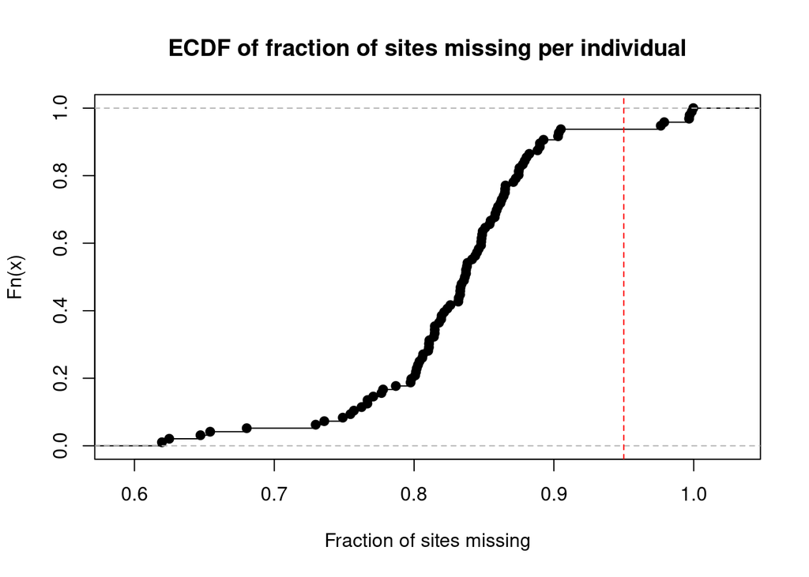

```r
missingness <- read.table('crepi.imiss', header = TRUE)
plot(ecdf(missingness$F_MISS),
     xlab = 'Fraction of sites missing',
     main = 'ECDF of fraction of sites missing per individual')
abline(v = 0.95, col = 'red', lty = 2)
```

```r
VeryBad <- as.character(missingness[missingness$F_MISS > 0.95, 'INDV'])
VeryBad
```

```
## [1] "N044Cx2" "N048Cma" "N048Cmb" "N048Cmc" "S031Cmc" "T165Cxa"
```

```r
write.table(VeryBad, file = 'VeryBad.txt', quote = FALSE, row.names = FALSE, col.names = FALSE)
```

Given the discontinuity in the distribution of missingness, it seems reasonable to draw a threshold at 95% of missing data. Out of 96 individuals, 90 are left.

```bash
VCF=../2023-05-18/crepi.vcf
if [ ! -e crepi_indv.recode.vcf ]; then
   vcftools --vcf $VCF \
            --out crepi_indv \
            --remove VeryBad.txt \
            --recode \
            --recode-INFO-all 1>> vcftools.log 2>> vcftools.err
fi
```

# Sites Missing and Filtering

After having removed the individuals with very low amounts of data, we can check the missingness by sites, and filter sites. We start from over 7 million sites, and it is not surprising that most of them are not genotyped in a large portion of samples.

## Missing Sites

```bash
if [ ! -e crepi.lmiss ]; then
   vcftools --vcf crepi_indv.recode.vcf \
            --out crepi \
            --missing-site 1>> vcftools.log 2>> vcftools.err
fi
```

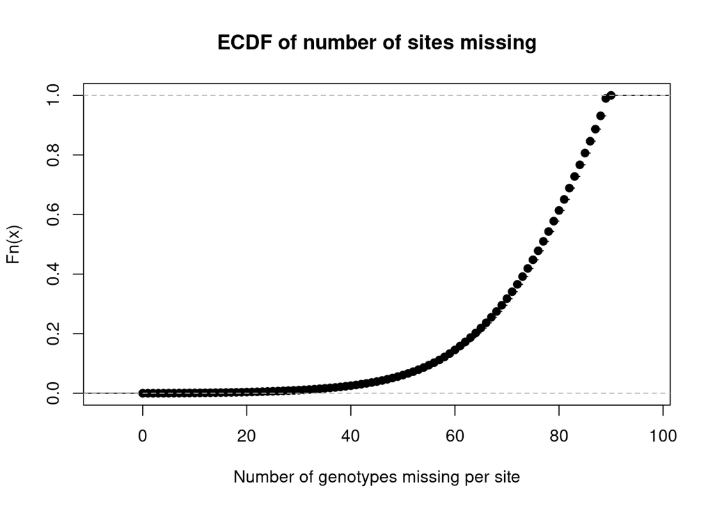

```r
missingsite <- read.table('crepi.lmiss', header = TRUE)
plot(ecdf(missingsite$N_MISS/2),
     xlab = 'Number of genotypes missing per site',
     main = 'ECDF of number of sites missing')
```

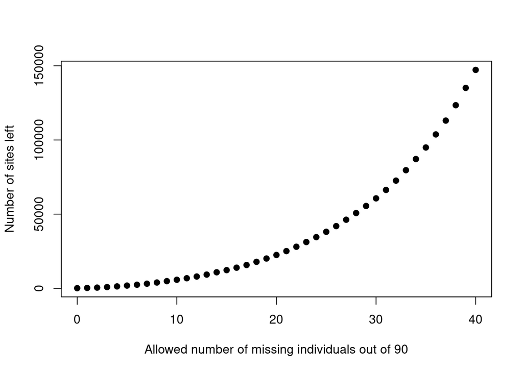

```r
plot(0:40, dim(missingsite)[1] * ecdf(missingsite$N_MISS/2)(0:40), pch = 19,
     ylab = 'Number of sites left', xlab = 'Allowed number of missing individuals out of 90')
```

I note that `vcftools` reports and filters missing chromosomes, not *genotypes*, and that’s why I divide by 2 above, to keep count of (diploid) individuals, instead of their chromosomes. Allowing no more than 30 genotypes missing in a site retrieves more han 50000 sites, which is good enough. We could use the filter `--max-missing-count 60` (because, again, `vcftools` counts chromosomes!) or `--max-missing 0.667`, because the name of this parameter is misleading and it actually means the minimum fraction of genotypes (or chromosomes) with data. We also apply the following filtering options to generate a cleaner data set

#### Position filtering

`--thin` Specified distance between one site and the next.

#### Variant type Filtering

`--remove-indels` Exclude sites that contain an idel (any variant that alters the lenght of the REF allele).

#### Info Field Filtering

`--mac` Include only sites with Minor Allele Count higher or equal to `--max-allels` Include only sites with a number of alleles lower or equal to

#### Genotype Value Filtering

`--max-meanDP` Includes only sites with mean depth values (over all included individuals) lower or equal to the . These options require that the “DP” FORMAT tag is included for each site. `--minGQ` Exclude all genotypes with a quality below the threshold specified. This option requires that the “GQ” FORMAT tag is specified for all sites.

#### VCF Output Options

`--recode` Generate a new .vcf file from the input after applying the filtering options specified. `--recode-INFO-all` Keep the INFO key present in the input file.

```bash
if [ ! -e summary_distances.txt ]; then
   gawk 'BEGIN{
      CURRENTCHROM = ""
      LASTPOS = 0
   }(/^[^#]/){
      if (($1 == CURRENTCHROM) && (LASTPOS > 0)){
         F[$2 - LASTPOS]++
         LASTPOS = $2
      } else {
         CURRENTCHROM = $1
         LASTPOS = $2
      }
   }END{
      for (f in F) print f "\t" F[f]
   }' crepi_indv.recode.vcf | \
   sort -nk 1,1 > summary_distances.txt
fi
```

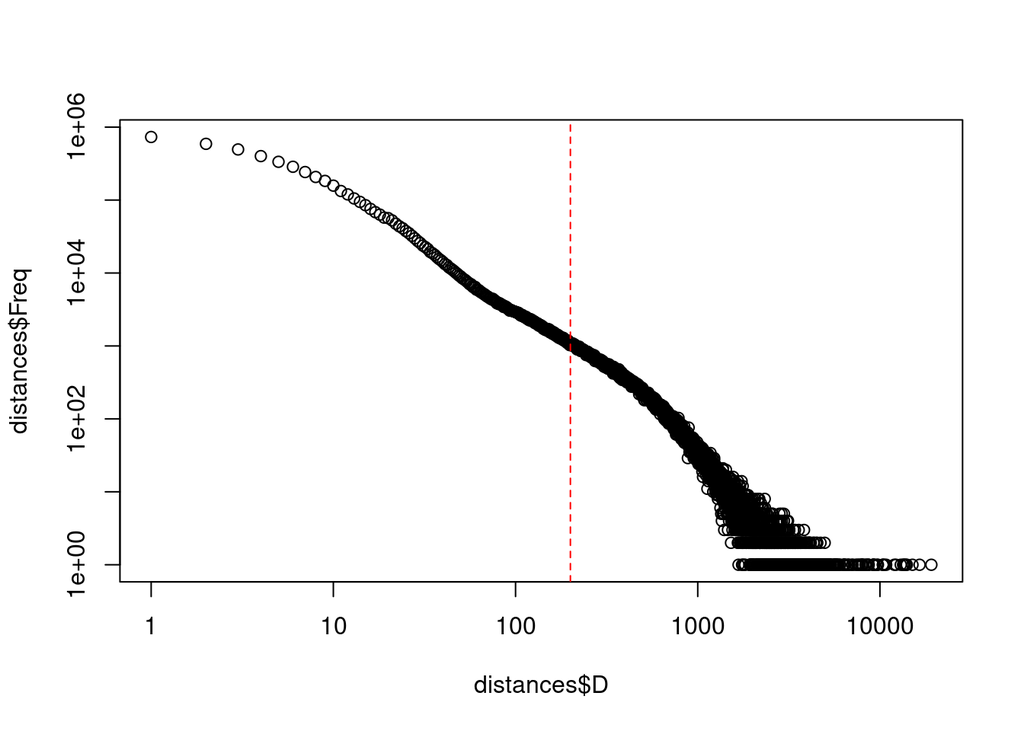

```r
distances <- read.table('summary_distances.txt',
                        col.names = c('D', 'Freq'))
plot(distances$D, distances$Freq, log = 'xy')
abline(v = 200, col = 'red', lty = 2)
```

```bash
if [ ! -e crepi_sites.recode.vcf ]; then
   vcftools --vcf crepi_indv.recode.vcf \
            --out crepi_sites \
            --thin 200 \
            --max-missing 0.667 \
            --remove-indels \
            --mac 2 \
            --max-meanDP 1000 \
            --recode --recode-INFO-all 1>> vcftools.log 2>> vcftools.err
fi
```

The `--thin 200` filter actually removes a lot of data, without being specially strict. Many pairs of SNPs will still be in linkage disequilibrium. This prevents us from using the VCF in any meaningful subsequent analysis. But it conveys some information about the nature of variation within our samples. Definitely, SNPs are much more tightly clustered than if randomly distributed among contigs. This is in part a consequence of discovering SNPs only close to restriction enzyme cutting sites. Without the information of read positions, we cannot evaluate if the number of SNPs per locus is well distributed or not. But the distances gathered above tell us that 60% of adjacent SNP pairs are less than 10 bases apart.